# 2. Single-site Changing PE

Chris Terry

2026-06-16

## Introduction and Packages

```r
knitr::opts_chunk$set(warning = FALSE, message = TRUE)
library(cmdstanr)
library(posterior)
library(statcomp)
library(tidyverse)
```

```r
library(cowplot)
library(grid)


source("R/pe_data_generation.R")
source("R/pe_model_postprocess.R")
source("R/pe_prior_calibration.R")
```

This script runs the second demonstration example using simulated data.

The source data is a single long time series where the external noise increases through time.

# NSB prior model for PE trends.

Annotated STAN model code to fit a linear dependency between time and the relative frequency of each of the motifs, and then to calculate the change in PE.

In this model the posterior of the PE at each of the supplied time points is also returned for ease of use. This is a derived quantity, not a directly fit value.

Time (T) is assumed to have been scaled and centred to range from −0.5 to +0.5.

`prior_only` is a binary flag. If 1, new data is not used other than to set the data structure, and the prior is returned.

Quantities:

$\theta$, $\eta$, $\beta$ terms are vectors of length the number of motifs (usually 6).

$\theta_0$ a baseline motif-probability simplex at $T = 0$. Because time is centred, this corresponds to the midpoint of the time series. $\theta_t$ is the expected motif distribution at time $T$

$\beta$ terms identify the response to the predictor variable (here time)

$\eta_t$ is the linear predictor for the motif probabilities. In some ways it is a convenience parameter built from constructed from the $\beta$ time regression.

The expected motif-probability vector is then:

$$\eta_t = log(\theta_0) + \beta_{time}
T$$

$$\theta_t=\operatorname{softmax}(\eta_t)$$

$$PE_t =-\sum_k
\theta_{k,t}log(\theta_{k,t}) / log(K)$$
Note that the softmax function implicitly centers the $\eta$ values.

```r
nsb_trend_model <- cmdstan_model("stan/core_02_single_site_linear_trend_optimised.stan")

nsb_trend_model
```

```
## // Core model 02: single-site linear trend in NSB-regularised PE
## // Built for cmdstan 2.39.0
## // NB Certain optimisation features require at least Stan 2.36.
## // This is currently ( summer 2026) *not* hosted on the CRAN rstan version
##
## // Purpose
## // -------
## // This model extends core_01_static_nsb_pe.stan by allowing the motif
## // probability vector to change linearly through time. It is intended for a
## // single reasonably long time series, where each motif event has a time value.
## // It is not build to handle gaps in the data.
## //
## // ------------------------------
## // The model does not fit "PE ~ time" directly. Instead, it fits a linear trend
## // in the motif probabilities on the logit scale, then derives PE from those
## // probabilities.
## // This is because entropy is a nonlinear summary of a
## // full motif distribution: many different motif shifts can produce the same PE.
## //
## // Data input
## // ---------------
## // The preprocessing layer should create one row per motif event:
## //
## //   y[n]           = integer motif label for event n, in 1...K
## //   time_scaled[n] = scaled centre time for that motif event
## //
## // time_scaled should usually be centered near zero and scaled to a sensible
## // range. With centered time, theta0 is interpretable as the mid-series motif
## // distribution.
## // It is this theta0 that recieves the NSB scaling.
##
## functions {
##   real nsb_weight_lp(real alpha, int k) {
##     real d_expected_h = k * trigamma(k * alpha + 1) - trigamma(alpha + 1);
##     return log(abs(d_expected_h));
##   }
##
##   vector centering(vector eta) {
##     return eta - mean(eta);
##   }
```

[output cut: 61 more lines]

```
##     matrix[1, K] beta_matrix = to_matrix(beta_time');
##
##     y ~ categorical_logit_glm(X, alpha, beta_matrix);
##   }
## }
##
## generated quantities {
##   // Posterior PE evaluated on the supplied time grid.
##   vector[G] pe_time;
##   array[G] vector[K] theta_time;
##   for (g in 1:G) {
##     theta_time[g] = softmax(log(theta0) + beta_time * time_grid_scaled[g]);
##     pe_time[g] = normalised_entropy(theta_time[g]);
##   }
## }
```

# Underlying Time Series Data

## Changing through time

The $\sigma$ of the underlying data increases linerly from 0.1 to 0.2 over the 1000 timesteps.

NB the simulate_feedback_sites() function includes a 100-step burn in period by default.

The increase in noise is only marginally visible from a quick look at the raw data.

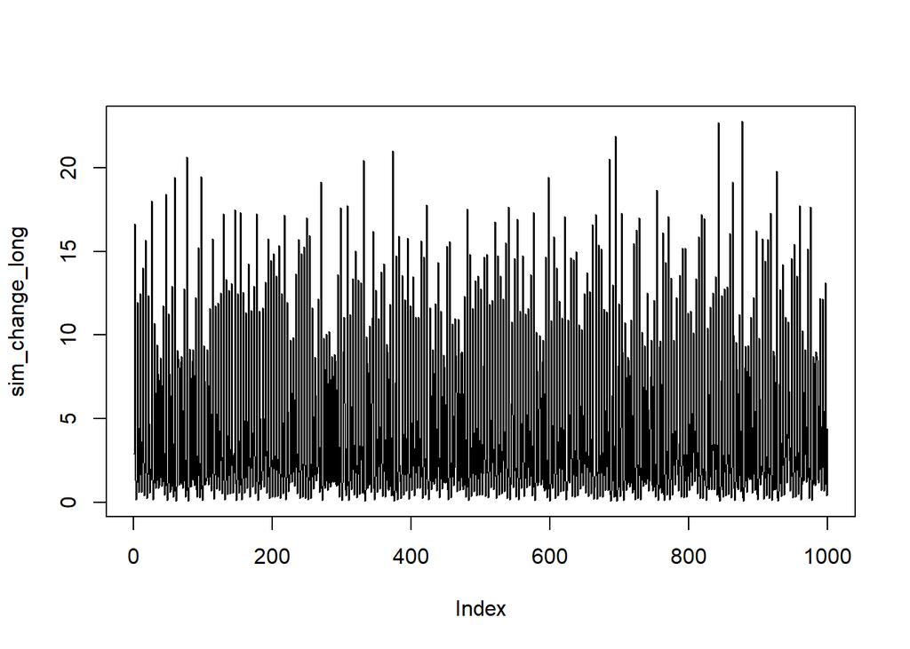

```r
AR2 = -1.1

sim_change<- simulate_feedback_sites(n_site = 2,n_year = 1000,
                                     delayed_feedback = AR2,
                                     sd_start = 0.1, sd_end = 0.2)

sim_change_long <- sim_change$abundance_matrix[,1]

plot(sim_change_long, type = 'l')
```

### Making Data bundle

Reformat the data into the form neded by the STAN function.

This includes specifying the prior on the response of motifs to time slope.

The model’s time-input is scaled: one centred unit makes one unit of beta a logit-scale change in relative motif frequency, although this remains quite complex to interpret on the simplex. Without some kind of regularisation, the model would have trouble converging.

How to determine the slope_prior_sd? This prior determines the expected spread of beta terms linking scaled time and the logit-scale relative motif frequencies. With the time range scaled to have a range of 1, this can be interpreted reasonably cleanly. A slope_prior_sd of 0.5 implies it is reasonable to expect some log-ratio shifts of around +/- 1, which is probably rather large.

Here a value of 0.75 is used to give the maximum responsiveness to the relatively large dataset used here. 0.5 is probably a more useful default when less data is available.

```r
make_data_bundle_single_site_trend <- function(y , m=3){
  Z <- ordinal_pattern_time_series(y, m)+1 # Vector of motifs, from 1
  Z <- Z[!is.na(Z)]
  N = length(Z)

  time_scaled = as.vector(seq( from = -0.5, to = 0.5, length = N))
  list(N = N,
       K = as.integer(factorial(m)),
       y = as.integer(Z),
       time_scaled=time_scaled,
       G = N,                           ## Predict on same scale and values as data
       time_grid_scaled = time_scaled,  ## Predict on same scale and values as data
       prior_only = 0L,
       slope_prior_sd = 0.75)
}

db <- make_data_bundle_single_site_trend(sim_change_long)
str(db)
```

```
## List of 8
##  $ N               : int 998
##  $ K               : int 6
##  $ y               : int [1:998] 5 6 3 1 4 6 3 1 4 6 ...
##  $ time_scaled     : num [1:998] -0.5 -0.499 -0.498 -0.497 -0.496 ...
##  $ G               : int 998
##  $ time_grid_scaled: num [1:998] -0.5 -0.499 -0.498 -0.497 -0.496 ...
##  $ prior_only      : int 0
##  $ slope_prior_sd  : num 0.75
```

### Finding ‘True’ PE Values

To numerically identify the ‘true’ value of the PE at various levels of $\sigma$, a set of long time series with fixed sd, are used to observe the ‘true’ PE.

```r
N_Sample_points<- 11

map( seq(0.1, 0.2, l=N_Sample_points), function(sd){
  sim<- simulate_feedback_sites(n_site = 2,n_year = 100000,
                                delayed_feedback = AR2,
                                sd_start = sd, sd_end = sd)
  return(sim$abundance_matrix[,1])})%>%
  map( ordinal_pattern_distribution, ndemb =3) -> TrueSeriesMotifDists

## Compare long series of fixed noise:
Underlying_Trend <- map_dbl(TrueSeriesMotifDists, permutation_entropy)

Underlying_Trend
```

```
##  [1] 0.9259421 0.9343271 0.9414366 0.9472344 0.9517834 0.9538866 0.9571993
##  [8] 0.9585305 0.9591965 0.9598608 0.9600080
```

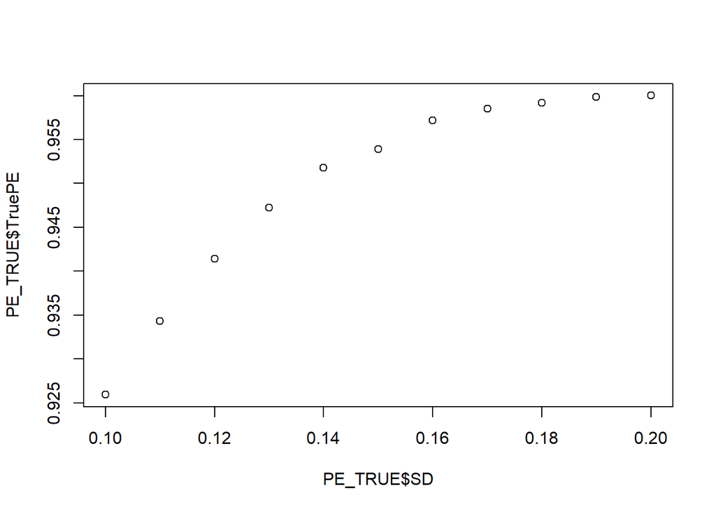

```r
PE_TRUE<-data.frame( TruePE = Underlying_Trend,
                     SD = seq(0.1, 0.2, l=N_Sample_points),
                     Scaled_time =seq(-0.5,  0.5, l=N_Sample_points))

plot(PE_TRUE$SD, PE_TRUE$TruePE)
```

# Fitting Model

```r
## takes about 1 minute to run

nsb_trend <-nsb_trend_model$sample(data = db,
                                   chains = 4, parallel_chains = 4,
                                   adapt_delta = 0.95, refresh = 0)

pe_time_df<- nsb_trend$summary(variables = c('pe_time', 'beta_time',
                                             'theta0', 'alpha_nsb',
                                             'theta_time'))
write_csv( pe_time_df, 'model fits/vars_time_df75.csv')
```

## Comparing fit to ‘true’ values

```r
vars_time_df.csv <- read_csv('model fits/vars_time_df75.csv')
```

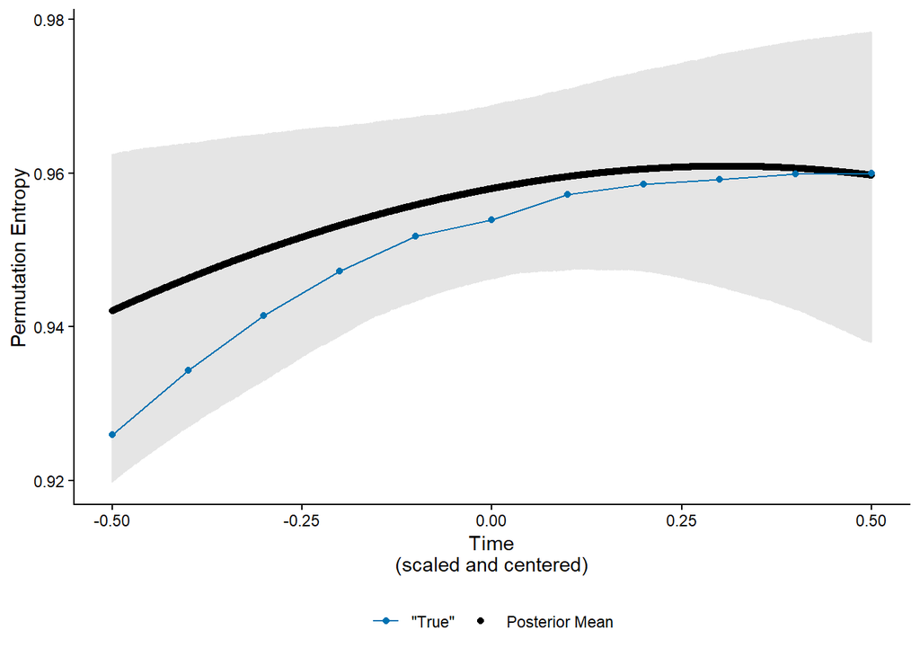

```r
vars_time_df.csv %>%
  filter( str_starts(variable,'pe_time'))%>%
  mutate( time_scaled = db$time_grid_scaled) %>%
  ggplot( aes(y = mean, x = time_scaled ))+
  geom_errorbar(aes ( ymin = q5, ymax = q95),
                col = 'grey90')+
  geom_point(aes (y = mean,
                  col = 'Posterior Mean'))+
  geom_line(data =PE_TRUE,
            aes(x = Scaled_time, y = TruePE,
                col = '"True"'))+
  geom_point(data =PE_TRUE,
             aes(x = Scaled_time, y = TruePE,
                 col = '"True"'))+
  theme_classic()+
  theme(legend.position = 'bottom')+
  xlab( 'Time\n(scaled and centered)')+
  ylab( 'Permutation Entropy' )+
  scale_colour_manual(values = c(  "Posterior Mean" = "black",
                                   '"True"' = "#0072B2" ),
                      name = NULL)-> PE_ThroughTime_Trial

PE_ThroughTime_Trial
```

### Changes in motif ratio

A deeper test of whether the model is capturing underlying trends.

‘True’ values here are calculated from long series at fixed noise levels.

```r
Motif_cols <- c(  "123" = "#4CAF65",  # increasing
  "132" = "#F48FA5",  # peak
  "213" = "#62A8E5",  # trough
  "231" = "#C83E68",  # peak
  "312" = "#3659B8",  # trough
  "321" = "#F0AD32"   # decreasing
)
truth_log_probs <- map_dfr(TrueSeriesMotifDists,
                           function(p) {
                             data.frame( motif = motif_labels_3,
                                         log_p_centered = log(p) - mean(log(p)),
                                         p = p/sum(p) )})

truth_time <- seq(-0.5, 0.5, length.out = length(TrueSeriesMotifDists))
sds <- seq(0.1, 0.2, l=N_Sample_points)
truth_log_probs$time_scaled = rep(truth_time, each = 6)
truth_log_probs$sd <- rep(sds, each = 6)
```

### Plotting Fitted Motif Probabilities against observed

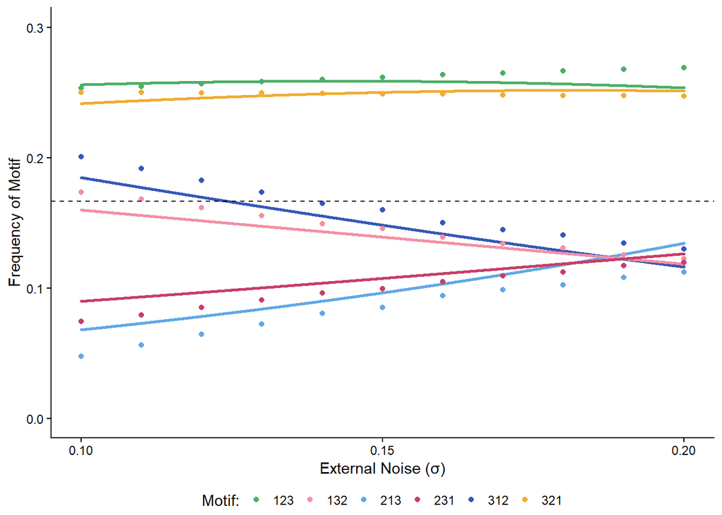

```r
vars_time_df.csv %>%
  filter(str_starts(variable, "theta_time") ) %>%
  mutate( time = as.numeric(str_extract(variable, "\\d+")),
          motif_id = as.numeric(str_extract(variable, "(?<=,)\\d+")),
          motif = motif_labels_3[motif_id]) %>%
  mutate( sd = seq(0.1, 0.2, l= 998)[time]) %>%
  ggplot( aes( x = sd, y =mean, col = motif))+
  geom_point( size= 0.5)+
  theme_classic()+
  scale_colour_manual( values = Motif_cols, name = 'Motif:')+
  scale_y_continuous(breaks = c( 0,0.1, 0.2, 0.3), limits =c( 0, 0.3))+
  scale_x_continuous(breaks = c(0.1,0.15, 0.2), limits =c( 0.1, 0.2))+
  ylab('Frequency of Motif')+
  xlab('External Noise (σ)')+
  guides(colour = guide_legend(nrow = 1,byrow = TRUE)) +
  geom_point(aes( y = p , x = sd, col = motif), data =truth_log_probs ) +
  theme(legend.position = "bottom",
        legend.margin = margin(t = 0, r = 0, b = 0, l = 0),
        legend.box.margin = margin(0, 0, 0, 0),
        legend.spacing.y = unit(0, "pt"),
        legend.key.height = unit(8, "pt"),
        legend.key.width = unit(12, "pt"))+
  geom_hline(yintercept = 1/6, linetype = 'dashed') -> MotifPatternsFitPlot

MotifPatternsFitPlot
```

## Combined figure

```r
demo2plot<- plot_grid(PE_ThroughTime_Trial, MotifPatternsFitPlot,
                      nrow = 1, rel_widths = c(3,3),scale = 0.95,
                      labels = c('c)',' d)' ), align = 'h')

saveRDS(demo2plot, "MS_figs/ggplot objects/demo2plot.rds")
ggsave(demo2plot, filename = 'MS_figs/ggplot objects/demo2plot.png', width = 9, height =3  )
```